## Binary Logistic Regression Case Study: ICU Mortality Risk Factor Model

### Background:

#### This Data is for a Study of Risk Factors Associated with ICU Mortality. Data was collected at Baystate Medicla Center, Springfield, Massachusetts.

### Source :

#### APPLIED LOGISTIC REGRESSION by DAVID W. HOSMER & STANLEY LEMESHOW pg no.253.

### Objective:

#### The objective is to investigate the relationship between various predictor variables listed in ICU Mortality data and the binary outcome variable “Vital Status” (STA), which indicates whether a patient lived (0) or died (1) during their stay in the Intensive Care Unit (ICU) at Baystate Medical Center, Springfield, Massachusetts. This analysis aims to identify and quantify the risk factors associated with ICU mortality based on the provided dataset.

### Import Libraries

```r
library(ggplot2)
library(dplyr)
library(ROCR)
library(car)
library(caret)
```

### Load Data

```r
masterdata<-read.csv("ICU Mortality.csv",header = T)

head(masterdata)
```

```
  SR.NO ID STA AGE SEX RACE SER CAN CRN INF CPR SYS HRA PRE TYP FRA PO2 PH PCO
1     1  8   0  27   1    1   0   0   0   1   0 142  88   0   1   0   0  0   0
2     2 12   0  59   0    1   0   0   0   0   0 112  80   1   1   0   0  0   0
3     3 14   0  77   0    1   1   0   0   0   0 100  70   0   0   0   0  0   0
4     4 28   0  54   0    1   0   0   0   1   0 142 103   0   1   1   0  0   0
5     5 32   0  87   1    1   1   0   0   1   0 110 154   1   1   0   0  0   0
6     6 38   0  69   0    1   0   0   0   1   0 110 132   0   1   0   1  0   0
  BIC CRE LOC
1   0   0   0
2   0   0   0
3   0   0   0
4   0   0   0
5   0   0   0
6   1   0   0
```

### Data Description

| Column | Description | Values |
| --- | --- | --- |
| ID | Identification Code |  |
| STA | Vital Status | 0 = Lived, 1 = Died |
| AGE | Age in Years |  |
| SEX | Sex | 0 = Male, 1 = Female |
| RACE | Race | 1 = White, 2 = Black, 3 = Other |
| SER | Service at ICU Admission | 0 = Medical, 1 = Surgical |
| CAN | Cancer Part of Present Problem | 0 = No, 1 = Yes |
| CRN | History of Chronic Renal Failure | 0 = No, 1 = Yes |
| INF | Infection Probable at ICU Admission | 0 = No, 1 = Yes |
| CPR | CPR Prior to ICU Admission | 0 = No, 1 = Yes |
| SYS | Systolic Blood Pressure at ICU Admission | mm Hg |
| HRA | Heart Rate at ICU Admission | Beats/Minute |
| PRE | Previous Admission to an ICU within 6 Months | 0 = No, 1 = Yes |
| TYP | Type of Admission | 0 = Elective, 1 = Emergency |
| FRA | Long Bone, Multiple, Neck, Single Area, or Hip Fracture | 0 = No, 1 = Yes |
| PO2 | PO2 from Initial Blood Gases | 0 = > 60, 1 = ≤ 60 |
| PH | PH from Initial Blood Gases | 0 = ≥ 7.25, 1 = < 7.25 |
| PCO | PCO2 from Initial Blood Gases | 0 = ≤ 45, 1 = > 45 |
| BIC | Bicarbonate from Initial Blood Gases | 0 = ≥ 18, 1 = < 18 |
| CRE | Creatinine from Initial Blood Gases | 0 = ≤ 2.0, 1 = > 2.0 |
| LOC | Level of Consciousness at ICU Admission | 0 = No Coma or Stupor, 1 = Deep Stupor, 2 = Coma |

### Vital Status Statistics

```r
masterdata$STA<-as.factor(masterdata$STA)
STA<-data.frame(table(masterdata$STA))
names(STA)<-c("Vital Status","N")
STA$Percentage<-round((STA$N/sum(STA$N))*100,2)
STA$`Vital Status`<-ifelse(STA$`Vital Status`==1,"Died","Lived")
```

| Vital Status | N | Percentage |
| --- | --- | --- |
| Lived | 160 | 80 |
| Died | 40 | 20 |

#### **Observations :**

#### The table shows that one out of five patients admitted to the ICU did not survive.

### Boxplot of AGE by Vital Status

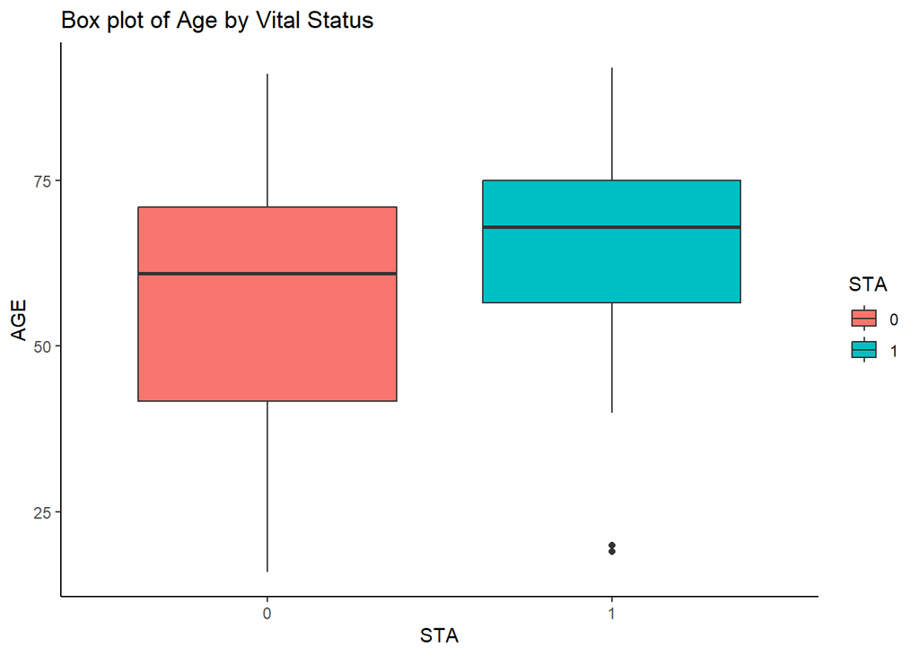

```r
ggplot(masterdata, aes(x=STA, y=AGE,fill=STA)) +
  ggtitle("Box plot of Age by Vital Status")+
  geom_boxplot()+theme_classic()
```

#### **Observations :**

#### Box-Whisker plot indicates that higher age is associated with ICU mortality.

### Boxplot of Systolic Blood Pressure by Vital Status

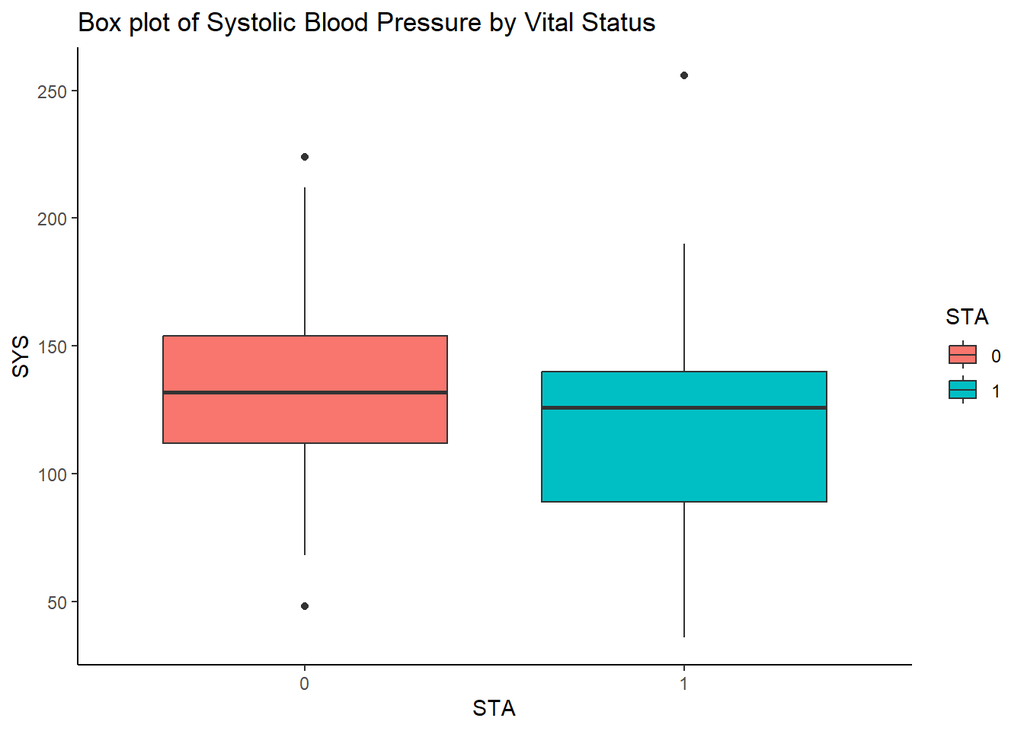

```r
ggplot(masterdata, aes(x=STA, y=SYS,fill=STA)) +
  ggtitle("Box plot of Systolic Blood Pressure by Vital Status")+
  geom_boxplot()+theme_classic()
```

#### **Observations :**

#### Low blood pressure is associated with high mortality rate.

### Boxplot of Heart Rate by Vital Status

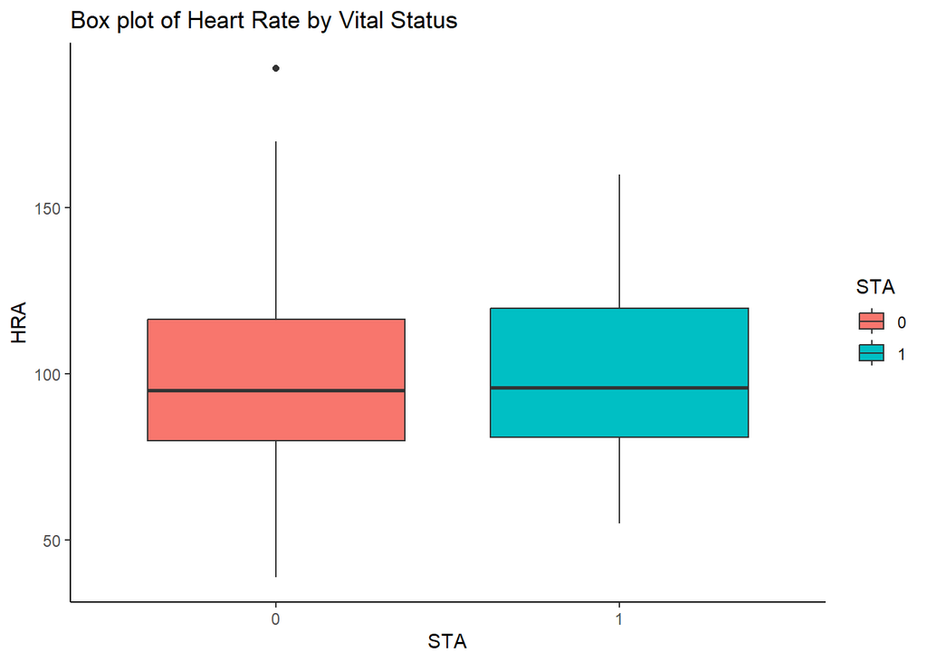

```r
ggplot(masterdata, aes(x=STA, y=HRA,fill=STA)) +
  ggtitle("Box plot of Heart Rate by Vital Status")+
  geom_boxplot()+theme_classic()
```

#### **Observations :**

#### Heart Rate (bases on median/quartiles) is not associated with ICU mortality.

### Sex - Based Mortality Statistics

```r
gender<-as.data.frame.matrix(table(masterdata$SEX,masterdata$STA))
names(gender)<-c("Lived","Died")
gender$N<-gender$Lived+gender$Died
gender$Gender<-ifelse(row.names(gender)==0,"Male","Female")
gender$Death_rate<-round((gender$Died/gender$N)*100,2)
gender<-gender %>% select(Gender,N,Death_rate)
```

| Gender | N | Death_rate |
| --- | --- | --- |
| Male | 124 | 19.35 |
| Female | 76 | 21.05 |

#### **Observations :**

#### The table shows a gender imbalance, with more males (124) than females (76), however the death rate was slightly higher among females (21.05% vs. 19.35%).

### Type Of Admission (TYP) - Based Mortality Statistics

```r
typad<-as.data.frame.matrix(table(masterdata$TYP,masterdata$STA))
names(typad)<-c("Lived","Died")
typad$N<-typad$Lived+typad$Died
typad$`Admission Type`<-ifelse(row.names(typad)==0,"Elective","Emergency")
typad$Death_rate<-round((typad$Died/typad$N)*100,2)
typad<-typad %>% select(`Admission Type`,N,Death_rate)
```

| Admission Type | N | Death_rate |
| --- | --- | --- |
| Elective | 53 | 3.77 |
| Emergency | 147 | 25.85 |

#### **Observations :**

#### As expected, patients admitted as emergency type shows higher ICU mortality rate as compared to elective admission.

### Level Of Consciousness (LOC) - Based Mortality Statistics

```r
locon<-as.data.frame.matrix(table(masterdata$LOC,masterdata$STA))
names(locon)<-c("Lived","Died")
locon$N<-locon$Lived+locon$Died
locon$`Level of Consciousness`<-ifelse(row.names(locon)==0,"No Coma or Stupor",ifelse(row.names(locon)==1,"Deep Stupor","Coma"))
locon$Death_rate<-round((locon$Died/locon$N)*100,2)
locon<-locon %>% select(`Level of Consciousness`,N,Death_rate)
```

| Level of Consciousness | N | Death_rate |
| --- | --- | --- |
| No Coma or Stupor | 185 | 14.59 |
| Deep Stupor | 5 | 100.00 |
| Coma | 10 | 80.00 |

#### **Observations :**

#### Level of consciousness at admission is clearly associated with ICU mortality. The mortality rate being highest for Deep Stupor followed by Coma and No Coma or Stupor.

### Logistic Regression Model

#### “LOC” values greater than 0, representing both “Deep Stupor” and “Coma,” are combined and denoted as 1 due to their limited occurrence for simplified analysis.

```r
masterdata$LOC<-ifelse(masterdata$LOC>0,1,0)
```

#### We are excluding the variable “RACE” from the analysis due to its skewed distribution, with a predominant number of instances classified as “WHITE” and minimal representation for “Black” and other racial categories.

```r
blr_model<-glm(STA~.-SR.NO-ID-RACE,data=masterdata,family = binomial)
summary(blr_model)
```

```
Call:
glm(formula = STA ~ . - SR.NO - ID - RACE, family = binomial,
    data = masterdata)

Coefficients:
              Estimate Std. Error z value Pr(>|z|)
(Intercept) -3.791e+00  1.858e+00  -2.040  0.04137 *
AGE          4.373e-02  1.599e-02   2.735  0.00624 **
SEX         -3.125e-01  4.815e-01  -0.649  0.51629
SER         -4.591e-01  5.707e-01  -0.805  0.42108
CAN         -1.459e+01  1.495e+03  -0.010  0.99221
CRN          1.712e-02  7.702e-01   0.022  0.98227
INF         -8.294e-03  5.342e-01  -0.016  0.98761
CPR          1.017e+00  9.321e-01   1.092  0.27501
SYS         -1.407e-02  7.769e-03  -1.811  0.07019 .
HRA         -3.117e-03  9.210e-03  -0.338  0.73504
PRE          6.321e-01  6.068e-01   1.042  0.29754
TYP          1.932e+00  9.565e-01   2.020  0.04341 *
FRA          8.281e-01  9.879e-01   0.838  0.40192
PO2          2.138e-01  7.763e-01   0.275  0.78298
PH           2.064e+00  1.085e+00   1.901  0.05724 .
PCO         -2.421e+00  1.180e+00  -2.051  0.04028 *
BIC         -8.013e-01  8.563e-01  -0.936  0.34942
CRE          5.011e-01  9.330e-01   0.537  0.59120
LOC          4.306e+00  1.081e+00   3.984 6.78e-05 ***
---
Signif. codes:  0 '***' 0.001 '**' 0.01 '*' 0.05 '.' 0.1 ' ' 1

(Dispersion parameter for binomial family taken to be 1)

    Null deviance: 200.16  on 199  degrees of freedom
Residual deviance: 130.40  on 181  degrees of freedom
AIC: 168.4

Number of Fisher Scoring iterations: 17
```

#### **Observations :**

#### The variables AGE (patient’s age), LOC (level of consciousness), TYP (type of admission) and PCO (PCO2 from initial blood gases) are statistically significant (p <= 0.05) risk factors associated with ICU mortality. Further, the variable SYS (Systolic Blood Pressure) and PH (PH from initial blood gases) is statistically significant at 10% level of significance (p=0.07 and 0.057).

### NOTE:

#### While our model includes several variables that are statistically insignificant, it is crucial to emphasize that in the healthcare domain, caution should be exercised when considering variable removal. In healthcare, even seemingly insignificant variables may hold clinical relevance or contribute to a comprehensive understanding of patient outcomes. Therefore, retaining these variables in the model allows for a more holistic analysis that aligns with the complex and multifaceted nature of healthcare data.

### Variance Inflation Factor (VIF) Analysis (checking Multicollinearity)

```r
vif(blr_model)
```

```
     AGE      SEX      SER      CAN      CRN      INF      CPR      SYS
1.490876 1.123196 1.563270 1.000000 1.329164 1.442442 1.195532 1.399281
     HRA      PRE      TYP      FRA      PO2       PH      PCO      BIC
1.327056 1.180287 1.277596 1.294443 1.353238 2.047266 2.280889 1.582621
     CRE      LOC
1.264426 1.514423
```

#### **Observations :**

#### It is observed that no variable has high vif. Hence the problem of multicollinearity does not exist.

### Evaluate Model Performance by Checking Area Under The ROC Curve

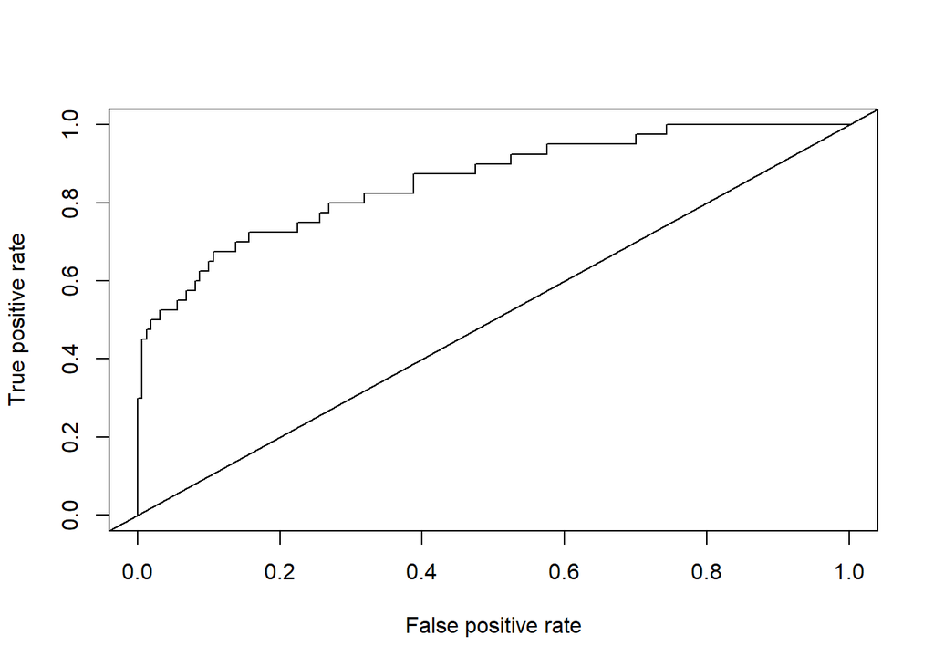

```r
masterdata$predprob<-fitted(blr_model)
pred<-prediction(masterdata$predprob,masterdata$STA)
perf<-performance(pred,"tpr","fpr")
plot(perf)
abline(0,1)
```

```r
auc<-performance(pred,"auc")
auc@y.values
```

```
[[1]]
[1] 0.8560937
```

#### **Observations :**

#### The model’s AUC of 85.6% indicates a relatively strong discriminative ability, implying good predictive performance.

### Finding the Best Threshold

```r
ss <- performance(pred, "sens", "spec")
best_threshold <- ss@alpha.values[[1]][which.max(ss@x.values[[1]]+ss@y.values[[1]])]
paste("Best Threshold is :",round(best_threshold,2))
```

```
[1] "Best Threshold is : 0.28"
```

### Classification Report

```r
masterdata$predY<-as.factor(ifelse(masterdata$predprob>best_threshold,1,0))
confusionMatrix(masterdata$predY,masterdata$STA,positive="1")
```

```
Confusion Matrix and Statistics

          Reference
Prediction   0   1
         0 143  14
         1  17  26

               Accuracy : 0.845
                 95% CI : (0.7873, 0.8922)
    No Information Rate : 0.8
    P-Value [Acc > NIR] : 0.06324

                  Kappa : 0.5289

 Mcnemar's Test P-Value : 0.71944

            Sensitivity : 0.6500
            Specificity : 0.8938
         Pos Pred Value : 0.6047
         Neg Pred Value : 0.9108
             Prevalence : 0.2000
         Detection Rate : 0.1300
   Detection Prevalence : 0.2150
      Balanced Accuracy : 0.7719

       'Positive' Class : 1
```

#### **Observations :**

#### The sensitivity and specificity values using optimum threshold are approximately 65% and 89% and the accuracy is approximately 84% indicating good model performance.